# Bənd Çətinlik İndeksi: p = (# doğru cavab)/(# total)

Klassik Test Nəzəriyyəsi - Bənd Analizi

Klassik Test Nəzəriyyəsi Kursu

2025-07-17

## 0.1 Dərsin Məqsədləri

✓ Bənd çətinlik indeksinin anlayışını və hesablanmasını öyrənmək  
✓ p = (# doğru cavab)/(# total) formulasını praktik tətbiq etmək  
✓ Optimal çətinlik səviyyələrini təyin etmək  
✓ Çətinlik və diskriminasiya arasındakı əlaqəni anlamaq  
✓ R-da bənd çətinlik analizlərini aparmaq

## 0.2 Əvvəlki Dərsdən Xatırladıqlarımız

**Dərs 10-da öyrəndiklərimiz:** - CTT modelinin əsas prinsipləri - Etibarlılıq və validlik anlayışları - Test performansının qiymətləndirilməsi - Bənd analizinin əhəmiyyəti

# 1 Bənd Çətinlik İndeksinin Əsasları

## 1.1 Çətinlik İndeksinin Təyini

**Bənd çətinlik indeksi (p)** - bəndi doğru cavablayan şəxslərin ümumi cavabverən sayına nisbətidir.

### 1.1.1 **p = (Doğru cavab verənlərin sayı) / (Ümumi cavabverən sayı)**

Bu formulada: - **p** = Çətinlik indeksi (0 ≤ p ≤ 1) - **Yüksək p** = Asan bənd (çox adam doğru cavablayır) - **Aşağı p** = Çətin bənd (az adam doğru cavablayır)

```r
# Çətinlik indeksinin konseptual izahı
difficulty_examples <- data.frame(
  Bənd = paste("Bənd", 1:8),
  Doğru_Cavab = c(45, 38, 42, 15, 8, 35, 28, 50),
  Ümumi_İştirakçı = rep(50, 8),
  p_İndeksi = c(45, 38, 42, 15, 8, 35, 28, 50) / 50,
  Çətinlik_Səviyyəsi = c("Asan", "Orta", "Orta", "Çətin", "Çox Çətin",
                          "Orta", "Orta-Çətin", "Çox Asan")
)

kable(difficulty_examples,
      caption = "Müxtəlif Bəndlər üçün Çətinlik İndeksi Nümunələri",
      digits = 3)
```

Müxtəlif Bəndlər üçün Çətinlik İndeksi Nümunələri

[output not shown]

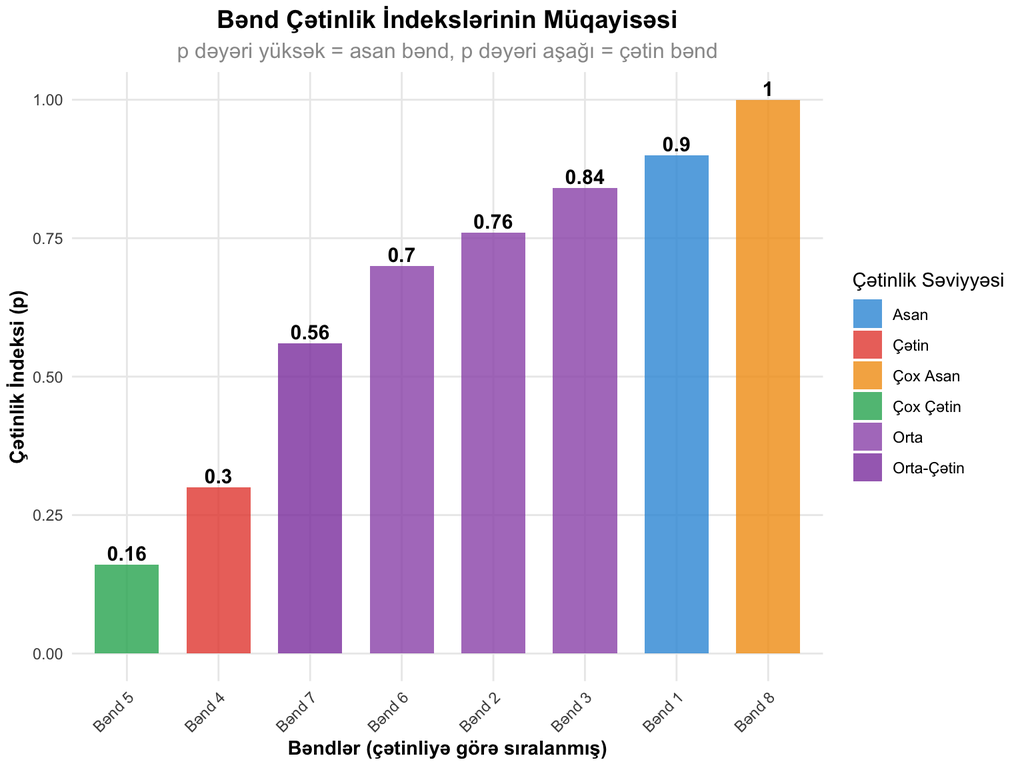

```r
# Çətinlik səviyyələrinin vizuallaşdırılması
ggplot(difficulty_examples, aes(x = reorder(Bənd, p_İndeksi), y = p_İndeksi,
                                fill = Çətinlik_Səviyyəsi)) +
  geom_col(alpha = 0.8, width = 0.7) +
  geom_text(aes(label = round(p_İndeksi, 2)),
            vjust = -0.3, fontface = "bold", size = 4) +
  scale_fill_manual(values = c("#3498db", "#e74c3c", "#f39c12", "#27ae60", "#9b59b6", "#8e44ad", "#2c3e50", "#16a085")) +
  labs(title = "Bənd Çətinlik İndekslərinin Müqayisəsi",
       subtitle = "p dəyəri yüksək = asan bənd, p dəyəri aşağı = çətin bənd",
       x = "Bəndlər (çətinliyə görə sıralanmış)",
       y = "Çətinlik İndeksi (p)",
       fill = "Çətinlik Səviyyəsi") +
  theme_clean() +
  theme(axis.text.x = element_text(angle = 45, hjust = 1))
```

## 1.2 Çətinlik Səviyyələrinin Təsnifatı

```r
# Çətinlik səviyyələrinin standart təsnifatı
classification <- data.frame(
  p_Aralığı = c("0.90 - 1.00", "0.70 - 0.89", "0.30 - 0.69", "0.11 - 0.29", "0.00 - 0.10"),
  Çətinlik_Səviyyəsi = c("Çox Asan", "Asan", "Orta", "Çətin", "Çox Çətin"),
  Tövsiyə = c("Çox asan - yenidən nəzərdən keçirin",
              "Test başlanğıcı üçün uyğun",
              "İdeal diskriminasiya potensialı",
              "Yüksək qabiliyyətlilər üçün",
              "Çox çətin - dəyişdirin"),
  Rəng_Kodu = c("#e74c3c", "#f39c12", "#27ae60", "#3498db", "#9b59b6")
)

kable(classification, caption = "Bənd Çətinlik Səviyyələrinin Standart Təsnifatı")
```

Bənd Çətinlik Səviyyələrinin Standart Təsnifatı

| p_Aralığı | Çətinlik_Səviyyəsi | Tövsiyə | Rəng_Kodu |
| --- | --- | --- | --- |
| 0.90 - 1.00 | Çox Asan | Çox asan - yenidən nəzərdən keçirin | #e74c3c |
| 0.70 - 0.89 | Asan | Test başlanğıcı üçün uyğun | #f39c12 |
| 0.30 - 0.69 | Orta | İdeal diskriminasiya potensialı | #27ae60 |
| 0.11 - 0.29 | Çətin | Yüksək qabiliyyətlilər üçün | #3498db |
| 0.00 - 0.10 | Çox Çətin | Çox çətin - dəyişdirin | #9b59b6 |

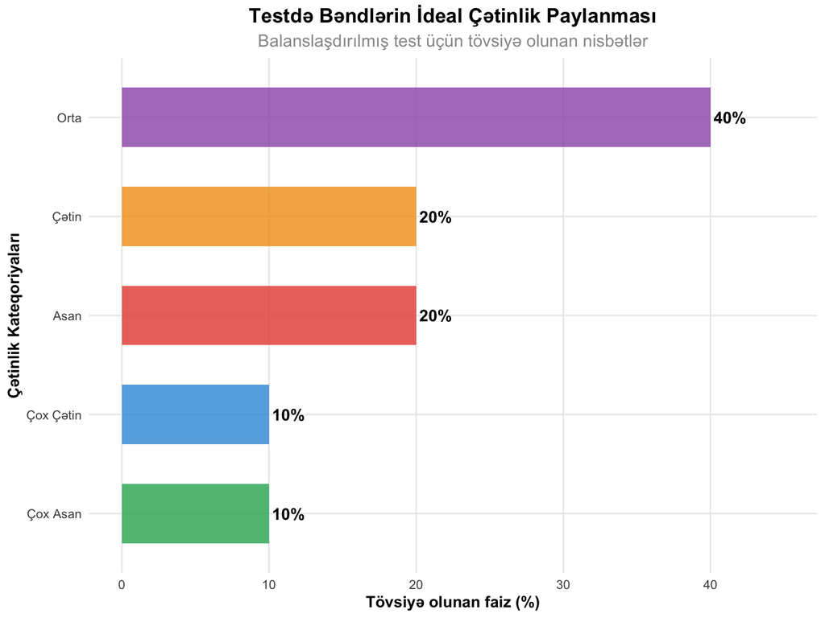

```r
# Çətinlik paylanmasının ideal modeli
ideal_distribution <- data.frame(
  Çətinlik_Kateqoriyası = classification$Çətinlik_Səviyyəsi,
  İdeal_Faiz = c(10, 20, 40, 20, 10),
  Rəng = classification$Rəng_Kodu
)

ggplot(ideal_distribution, aes(x = reorder(Çətinlik_Kateqoriyası, İdeal_Faiz),
                               y = İdeal_Faiz, fill = Çətinlik_Kateqoriyası)) +
  geom_col(alpha = 0.8, width = 0.6) +
  geom_text(aes(label = paste0(İdeal_Faiz, "%")),
            hjust = -0.1, fontface = "bold", size = 4) +
  coord_flip() +
  scale_fill_manual(values = ideal_distribution$Rəng) +
  labs(title = "Testdə Bəndlərin İdeal Çətinlik Paylanması",
       subtitle = "Balanslaşdırılmış test üçün tövsiyə olunan nisbətlər",
       x = "Çətinlik Kateqoriyaları", y = "Tövsiyə olunan faiz (%)") +
  theme_clean() +
  theme(legend.position = "none") +
  ylim(0, 45)
```

# 2 Çətinlik İndeksinin Hesablanması

## 2.1 Əsas Hesablama Metodları

```r
# Nümunə test məlumatları yaradılması
set.seed(123)
n_students <- 100
n_items <- 10

# Müxtəlif çətinlik səviyyələri ilə test yaradılması
item_difficulties <- c(0.9, 0.8, 0.7, 0.6, 0.5, 0.4, 0.3, 0.2, 0.15, 0.1)

# Test cavablarının simulyasiyası
test_data <- matrix(0, nrow = n_students, ncol = n_items)
colnames(test_data) <- paste0("Bənd_", 1:n_items)

for(i in 1:n_items) {
  # Hər bənd üçün cavablar (Bernoulli paylanması)
  test_data[, i] <- rbinom(n_students, 1, item_difficulties[i])
}

# Çətinlik indekslərinin hesablanması
observed_difficulties <- apply(test_data, 2, mean)

# Nəticələrin müqayisəsi
difficulty_comparison <- data.frame(
  Bənd = paste0("Bənd_", 1:n_items),
  Nəzəri_p = item_difficulties,
  Müşahidə_p = round(observed_difficulties, 3),
  Fərq = round(abs(item_difficulties - observed_difficulties), 3),
  Doğru_Cavab_Sayı = apply(test_data, 2, sum),
  İştirakçı_Sayı = rep(n_students, n_items)
)

kable(difficulty_comparison,
      caption = "Nəzəri və Müşahidə Olunan Çətinlik İndekslərinin Müqayisəsi")
```

Nəzəri və Müşahidə Olunan Çətinlik İndekslərinin Müqayisəsi

|  | Bənd | Nəzəri_p | Müşahidə_p | Fərq | Doğru_Cavab_Sayı | İştirakçı_Sayı |
| --- | --- | --- | --- | --- | --- | --- |
| Bənd_1 | Bənd_1 | 0.90 | 0.93 | 0.03 | 93 | 100 |
| Bənd_2 | Bənd_2 | 0.80 | 0.81 | 0.01 | 81 | 100 |
| Bənd_3 | Bənd_3 | 0.70 | 0.71 | 0.01 | 71 | 100 |
| Bənd_4 | Bənd_4 | 0.60 | 0.61 | 0.01 | 61 | 100 |
| Bənd_5 | Bənd_5 | 0.50 | 0.46 | 0.04 | 46 | 100 |
| Bənd_6 | Bənd_6 | 0.40 | 0.39 | 0.01 | 39 | 100 |
| Bənd_7 | Bənd_7 | 0.30 | 0.35 | 0.05 | 35 | 100 |
| Bənd_8 | Bənd_8 | 0.20 | 0.21 | 0.01 | 21 | 100 |
| Bənd_9 | Bənd_9 | 0.15 | 0.12 | 0.03 | 12 | 100 |
| Bənd_10 | Bənd_10 | 0.10 | 0.11 | 0.01 | 11 | 100 |

## 2.2 R-da Praktik Hesablama

```r
# CTT paketi ilə çətinlik analizləri
library(CTT)

# Çətinlik statistikalarının hesablanması
item_stats <- itemAnalysis(test_data)

# Əsas çətinlik məlumatları
difficulty_stats <- data.frame(
  Bənd = paste0("Bənd_", 1:n_items),
  Çətinlik_p = round(item_stats$itemReport$pBis, 3),
  Standart_Xəta = round(sqrt(item_stats$itemReport$pBis *
                             (1 - item_stats$itemReport$pBis) / n_students), 3),
  Alt_Hədd_95 = round(item_stats$itemReport$pBis -
                      1.96 * sqrt(item_stats$itemReport$pBis *
                                  (1 - item_stats$itemReport$pBis) / n_students), 3),
  Üst_Hədd_95 = round(item_stats$itemReport$pBis +
                      1.96 * sqrt(item_stats$itemReport$pBis *
                                  (1 - item_stats$itemReport$pBis) / n_students), 3)
)

kable(difficulty_stats, caption = "Çətinlik İndekslərinin Ətraflı Statistik Analizi")
```

Çətinlik İndekslərinin Ətraflı Statistik Analizi

[output not shown]

```r
# Manual hesablama funksiyası
calculate_difficulty <- function(responses) {
  # responses: 0 və 1-lərdən ibarət vektor
  p <- mean(responses, na.rm = TRUE)
  se <- sqrt(p * (1 - p) / length(responses))

  return(list(
    difficulty = p,
    standard_error = se,
    confidence_interval = c(p - 1.96 * se, p + 1.96 * se)
  ))
}

# Nümunə hesablama
example_item <- test_data[, 1]
result <- calculate_difficulty(example_item)

cat("Bənd 1 üçün çətinlik analizi:\n")
```

```
## Bənd 1 üçün çətinlik analizi:
```

```r
cat("Çətinlik indeksi (p):", round(result$difficulty, 3), "\n")
```

```
## Çətinlik indeksi (p): 0.93
```

```r
cat("Standart xəta:", round(result$standard_error, 3), "\n")
```

```
## Standart xəta: 0.026
```

```r
cat("95% etibar intervalı: [", round(result$confidence_interval[1], 3),
    ", ", round(result$confidence_interval[2], 3), "]\n")
```

```
## 95% etibar intervalı: [ 0.88 ,  0.98 ]
```

# 3 Optimal Çətinlik Səviyyəsi

## 3.1 Optimal Çətinlik Nəzəriyyəsi

**Nəzəri əsaslar:** - **Maksimum diskriminasiya** üçün p = 0.50 optimal - **Test məqsədi** çətinlik səviyyəsini təyin edir - **Seçim testləri** üçün p = 0.60-0.70 uyğun - **Hərtərəfli qiymətləndirmə** üçün geniş spektr lazım

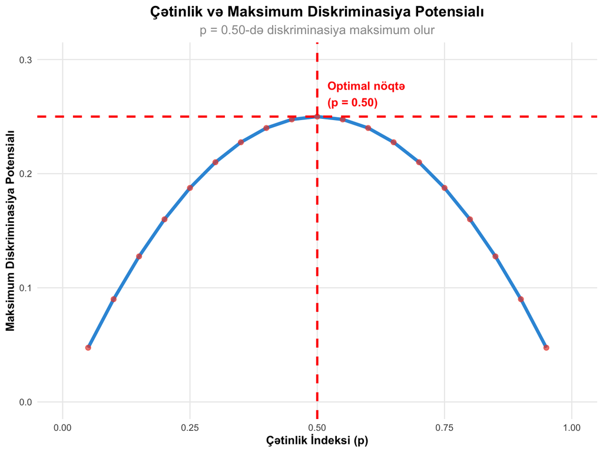

```r
# Optimal çətinlik və diskriminasiya əlaqəsi
p_values <- seq(0.05, 0.95, by = 0.05)
max_discrimination <- p_values * (1 - p_values)  # Variansın maksimumu

optimal_data <- data.frame(
  p_Dəyəri = p_values,
  Maksimum_Diskriminasiya = max_discrimination,
  Nəzəri_Variansa = p_values * (1 - p_values)
)

# Optimal nöqtənin vizuallaşdırılması
ggplot(optimal_data, aes(x = p_Dəyəri, y = Maksimum_Diskriminasiya)) +
  geom_line(size = 1.5, color = colors_basic[1]) +
  geom_point(size = 2, alpha = 0.7, color = colors_basic[2]) +
  geom_vline(xintercept = 0.5, linetype = "dashed", color = "red", size = 1) +
  geom_hline(yintercept = 0.25, linetype = "dashed", color = "red", size = 1) +
  annotate("text", x = 0.52, y = 0.27, label = "Optimal nöqtə\n(p = 0.50)",
           hjust = 0, color = "red", fontface = "bold") +
  labs(title = "Çətinlik və Maksimum Diskriminasiya Potensialı",
       subtitle = "p = 0.50-də diskriminasiya maksimum olur",
       x = "Çətinlik İndeksi (p)", y = "Maksimum Diskriminasiya Potensialı") +
  theme_clean() +
  xlim(0, 1) + ylim(0, 0.3)
```

## 3.2 Müxtəlif Test Növləri üçün Optimal Çətinlik

```r
# Müxtəlif test növləri üçün tövsiyələr
test_recommendations <- data.frame(
  Test_Növü = c("Qəbul İmtahanları", "Dərsdaxili Qiymətləndirmə", "Sertifikat Testləri",
                 "Diagnostik Testlər", "Tədris Materialı", "Araşdırma Testləri"),
  Optimal_p_Aralığı = c("0.60 - 0.70", "0.40 - 0.80", "0.70 - 0.80",
                        "0.30 - 0.90", "0.70 - 0.90", "0.20 - 0.80"),
  Əsas_Məqsəd = c("Seçim və ranksıralama", "Öyrənmənin qiymətləndirilməsi",
                  "Minimum çatışmada qərar", "Güclü və zəif tərəflərin təyini",
                  "Öyrənməni asanlaşdırma", "Teoriyanın yoxlanılması"),
  Diskriminasiya_Prioriteti = c("Yüksək", "Orta", "Aşağı", "Yüksək", "Aşağı", "Yüksək")
)

kable(test_recommendations, caption = "Müxtəlif Test Növləri üçün Optimal Çətinlik Tövsiyələri")
```

Müxtəlif Test Növləri üçün Optimal Çətinlik Tövsiyələri

| Test_Növü | Optimal_p_Aralığı | Əsas_Məqsəd | Diskriminasiya_Prioriteti |
| --- | --- | --- | --- |
| Qəbul İmtahanları | 0.60 - 0.70 | Seçim və ranksıralama | Yüksək |
| Dərsdaxili Qiymətləndirmə | 0.40 - 0.80 | Öyrənmənin qiymətləndirilməsi | Orta |
| Sertifikat Testləri | 0.70 - 0.80 | Minimum çatışmada qərar | Aşağı |
| Diagnostik Testlər | 0.30 - 0.90 | Güclü və zəif tərəflərin təyini | Yüksək |
| Tədris Materialı | 0.70 - 0.90 | Öyrənməni asanlaşdırma | Aşağı |
| Araşdırma Testləri | 0.20 - 0.80 | Teoriyanın yoxlanılması | Yüksək |

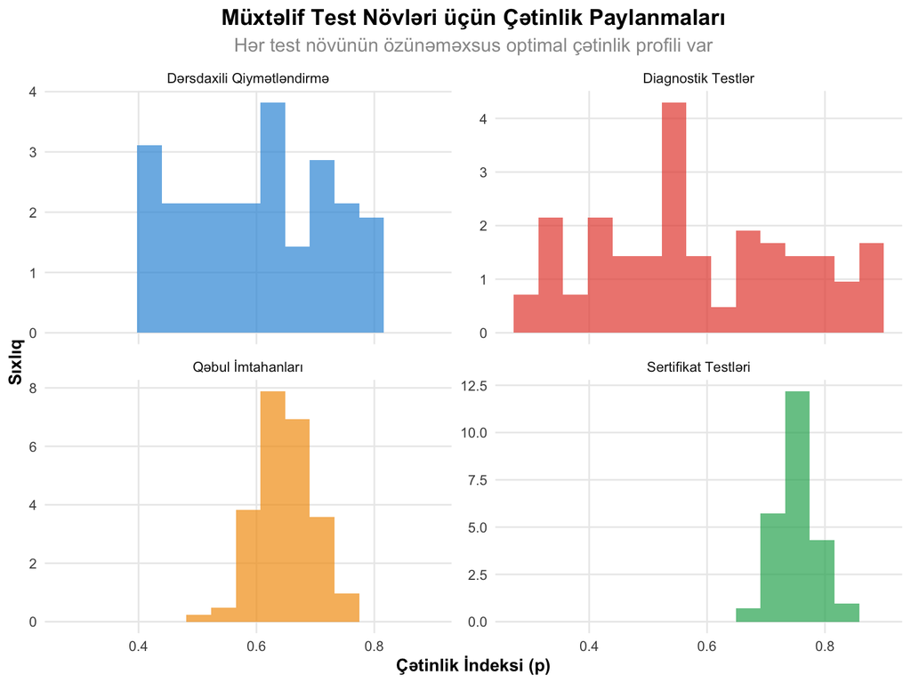

```r
# Test növlərinin çətinlik paylanması
test_difficulty_dist <- data.frame(
  Test_Növü = rep(test_recommendations$Test_Növü[1:4], each = 100),
  p_Dəyərləri = c(
    rnorm(100, 0.65, 0.05),  # Qəbul imtahanları
    runif(100, 0.4, 0.8),    # Dərsdaxili qiymətləndirmə
    rnorm(100, 0.75, 0.03),  # Sertifikat testləri
    runif(100, 0.3, 0.9)     # Diagnostik testlər
  )
)

# Paylanmaların müqayisəsi
ggplot(test_difficulty_dist, aes(x = p_Dəyərləri, fill = Test_Növü)) +
  geom_histogram(aes(y = after_stat(density)), bins = 15, alpha = 0.7) +
  facet_wrap(~Test_Növü, scales = "free_y") +
  scale_fill_manual(values = colors_basic[1:4]) +
  labs(title = "Müxtəlif Test Növləri üçün Çətinlik Paylanmaları",
       subtitle = "Hər test növünün özünəməxsus optimal çətinlik profili var",
       x = "Çətinlik İndeksi (p)", y = "Sıxlıq") +
  theme_clean() +
  theme(legend.position = "none")
```

# 4 Çətinlik və Diskriminasiya Əlaqəsi

## 4.1 Diskriminasiya Gücünün Anlayışı

**Diskriminasiya** - bəndin yüksək və aşağı qabiliyyətli şəxsləri ayırd etmə qabiliyyətidir.

```r
# Diskriminasiya və çətinlik əlaqəsinin praktik analizi

# Test məlumatlarından ümumi balları hesablayaq
total_scores <- rowSums(test_data)

# Tələbələri yüksək və aşağı qruplara ayıraq (27% metodu)
n_extreme <- round(0.27 * n_students)
high_group_indices <- order(total_scores, decreasing = TRUE)[1:n_extreme]
low_group_indices <- order(total_scores, decreasing = FALSE)[1:n_extreme]

# Hər bənd üçün diskriminasiya indeksi
discrimination_analysis <- data.frame(
  Bənd = paste0("Bənd_", 1:n_items),
  Ümumi_p = round(observed_difficulties, 3),
  Yüksək_Qrup_p = round(apply(test_data[high_group_indices, ], 2, mean), 3),
  Aşağı_Qrup_p = round(apply(test_data[low_group_indices, ], 2, mean), 3),
  Diskriminasiya_D = round(apply(test_data[high_group_indices, ], 2, mean) -
                           apply(test_data[low_group_indices, ], 2, mean), 3)
)

kable(discrimination_analysis,
      caption = "Çətinlik və Diskriminasiya İndekslərinin Birgə Analizi")
```

Çətinlik və Diskriminasiya İndekslərinin Birgə Analizi

|  | Bənd | Ümumi_p | Yüksək_Qrup_p | Aşağı_Qrup_p | Diskriminasiya_D |
| --- | --- | --- | --- | --- | --- |
| Bənd_1 | Bənd_1 | 0.93 | 0.963 | 0.815 | 0.148 |
| Bənd_2 | Bənd_2 | 0.81 | 0.926 | 0.667 | 0.259 |
| Bənd_3 | Bənd_3 | 0.71 | 0.963 | 0.519 | 0.444 |
| Bənd_4 | Bənd_4 | 0.61 | 0.815 | 0.333 | 0.481 |
| Bənd_5 | Bənd_5 | 0.46 | 0.778 | 0.222 | 0.556 |
| Bənd_6 | Bənd_6 | 0.39 | 0.630 | 0.185 | 0.444 |
| Bənd_7 | Bənd_7 | 0.35 | 0.407 | 0.148 | 0.259 |
| Bənd_8 | Bənd_8 | 0.21 | 0.333 | 0.148 | 0.185 |
| Bənd_9 | Bənd_9 | 0.12 | 0.259 | 0.111 | 0.148 |
| Bənd_10 | Bənd_10 | 0.11 | 0.259 | 0.037 | 0.222 |

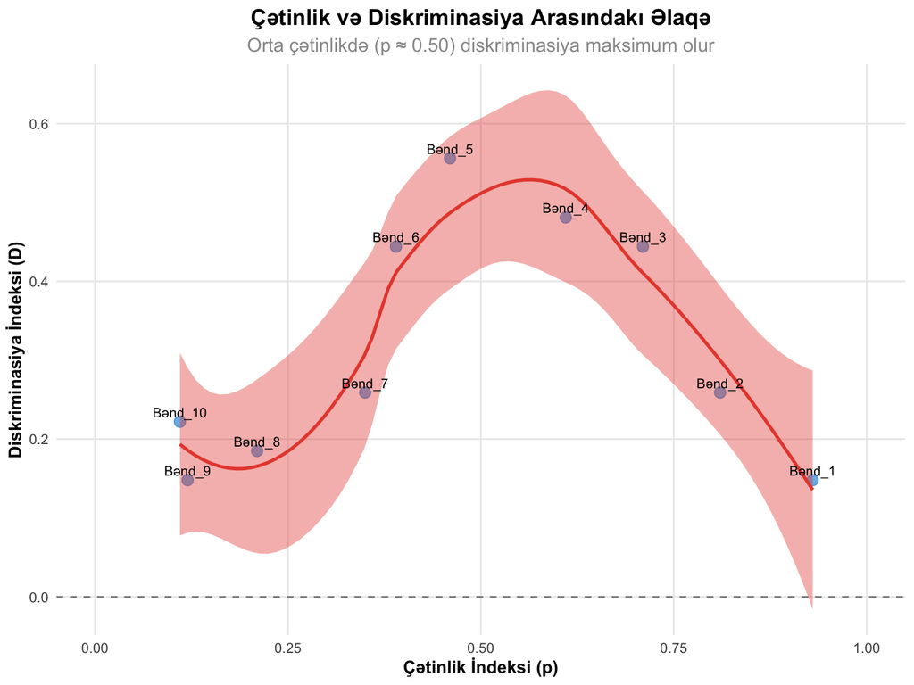

```r
# Çətinlik-Diskriminasiya qarşılıqlı təsiri
ggplot(discrimination_analysis, aes(x = Ümumi_p, y = Diskriminasiya_D)) +
  geom_point(size = 3, alpha = 0.7, color = colors_basic[1]) +
  geom_smooth(method = "loess", se = TRUE, color = colors_basic[2], fill = colors_basic[2]) +
  geom_hline(yintercept = 0, linetype = "dashed", alpha = 0.5) +
  geom_text(aes(label = Bənd), vjust = -0.5, size = 3) +
  labs(title = "Çətinlik və Diskriminasiya Arasındakı Əlaqə",
       subtitle = "Orta çətinlikdə (p ≈ 0.50) diskriminasiya maksimum olur",
       x = "Çətinlik İndeksi (p)", y = "Diskriminasiya İndeksi (D)") +
  theme_clean() +
  xlim(0, 1)
```

## 4.2 Çətinlik-Diskriminasiya Matrisi

```r
# Çətinlik və diskriminasiya əsasında bənd kateqoriyaları
categorize_items <- function(p, D) {
  if (D >= 0.30) {
    if (p >= 0.70) return("Asan və Yaxşı")
    else if (p >= 0.30) return("Optimal")
    else return("Çətin və Yaxşı")
  } else if (D >= 0.20) {
    if (p >= 0.70) return("Asan və Orta")
    else if (p >= 0.30) return("Yaxşı")
    else return("Çətin və Orta")
  } else {
    if (p >= 0.70) return("Asan və Zəif")
    else if (p >= 0.30) return("Zəif")
    else return("Çətin və Zəif")
  }
}

# Bəndlərin kateqoriyalaşdırılması
discrimination_analysis$Kateqoriya <- mapply(categorize_items,
                                           discrimination_analysis$Ümumi_p,
                                           discrimination_analysis$Diskriminasiya_D)

# Kateqoriya cədvəli
category_summary <- discrimination_analysis %>%
  count(Kateqoriya) %>%
  mutate(Faiz = round(n/sum(n)*100, 1))

kable(category_summary, caption = "Bəndlərin Çətinlik-Diskriminasiya Kateqoriyaları")
```

Bəndlərin Çətinlik-Diskriminasiya Kateqoriyaları

| Kateqoriya | n | Faiz |
| --- | --- | --- |
| Asan və Orta | 1 | 10 |
| Asan və Yaxşı | 1 | 10 |
| Asan və Zəif | 1 | 10 |
| Optimal | 3 | 30 |
| Yaxşı | 1 | 10 |
| Çətin və Orta | 1 | 10 |
| Çətin və Zəif | 2 | 20 |

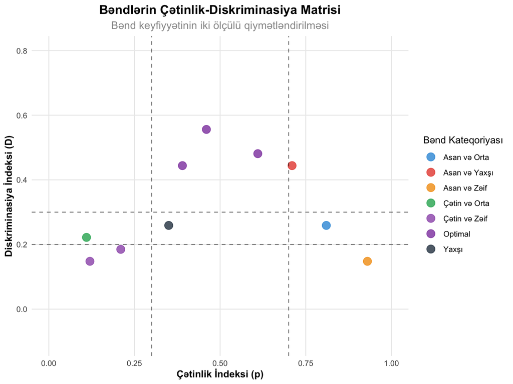

```r
# Matrisin vizuallaşdırılması
ggplot(discrimination_analysis, aes(x = Ümumi_p, y = Diskriminasiya_D,
                                   color = Kateqoriya)) +
  geom_point(size = 4, alpha = 0.8) +
  geom_vline(xintercept = c(0.30, 0.70), linetype = "dashed", alpha = 0.5) +
  geom_hline(yintercept = c(0.20, 0.30), linetype = "dashed", alpha = 0.5) +
  scale_color_manual(values = c("#3498db", "#e74c3c", "#f39c12", "#27ae60", "#9b59b6", "#8e44ad", "#2c3e50")) +
  labs(title = "Bəndlərin Çətinlik-Diskriminasiya Matrisi",
       subtitle = "Bənd keyfiyyətinin iki ölçülü qiymətləndirilməsi",
       x = "Çətinlik İndeksi (p)", y = "Diskriminasiya İndeksi (D)",
       color = "Bənd Kateqoriyası") +
  theme_clean() +
  xlim(0, 1) + ylim(-0.1, 0.8)
```

# 5 Çətinlik Analizində Praktik Problemlər

## 5.1 Tez-tez Rast Gəlinən Problemlər

```r
# Problem hallarının simulyasiyası
problematic_scenarios <- data.frame(
  Problem_Növü = c("Tavanefekti", "Döşəməefekti", "Qeyri-funksional seçimlər",
                   "İkiqat yükləmə", "Mədəni qərəzlik", "Texniki xəta"),
  Xarakteristika = c("p > 0.90, D ≈ 0", "p < 0.10, D ≈ 0", "Yanlış seçimlərin cəlbediciliği",
                     "Bir neçə bacarığı ölçür", "Müəyyən qrupa qarşı qərəzlik",
                     "Açar xətası, çaşdırıcı təlimat"),
  Təsir = c("Diskriminasiya itir", "Diskriminasiya itir", "Neqativ diskriminasiya",
            "Çətinlik interpretasiyası", "Qeyri-ədalətli ölçmə", "Səhv nəticələr"),
  Həll_Yolu = c("Bəndi çətinləşdir", "Bəndi asanlaşdır", "Distractorları yaxşılaşdır",
                "Bəndi sadələşdir", "Mədəni nəzərdən keçir", "Texniki yoxlama")
)

kable(problematic_scenarios, caption = "Çətinlik Analizində Tez-tez Rast Gəlinən Problemlər")
```

Çətinlik Analizində Tez-tez Rast Gəlinən Problemlər

| Problem_Növü | Xarakteristika | Təsir | Həll_Yolu |
| --- | --- | --- | --- |
| Tavanefekti | p > 0.90, D ≈ 0 | Diskriminasiya itir | Bəndi çətinləşdir |
| Döşəməefekti | p < 0.10, D ≈ 0 | Diskriminasiya itir | Bəndi asanlaşdır |
| Qeyri-funksional seçimlər | Yanlış seçimlərin cəlbediciliği | Neqativ diskriminasiya | Distractorları yaxşılaşdır |
| İkiqat yükləmə | Bir neçə bacarığı ölçür | Çətinlik interpretasiyası | Bəndi sadələşdir |
| Mədəni qərəzlik | Müəyyən qrupa qarşı qərəzlik | Qeyri-ədalətli ölçmə | Mədəni nəzərdən keçir |
| Texniki xəta | Açar xətası, çaşdırıcı təlimat | Səhv nəticələr | Texniki yoxlama |

```r
# Problemli bəndlərin simulyasiyası
set.seed(456)
n_prob_students <- 50

# Tavanefekti (çox asan)
ceiling_item <- rbinom(n_prob_students, 1, 0.95)

# Döşəməefekti (çox çətin)
floor_item <- rbinom(n_prob_students, 1, 0.05)

# Normal bənd
normal_item <- rbinom(n_prob_students, 1, 0.50)

problem_comparison <- data.frame(
  Bənd_Növü = c("Tavanefekti", "Döşəməefekti", "Normal"),
  p_İndeksi = c(mean(ceiling_item), mean(floor_item), mean(normal_item)),
  Variansa = c(var(ceiling_item), var(floor_item), var(normal_item)),
  Standart_Sapma = c(sd(ceiling_item), sd(floor_item), sd(normal_item))
)

kable(problem_comparison, caption = "Problemli Bəndlərin Statistik Xarakteristikaları",
      digits = 3)
```

Problemli Bəndlərin Statistik Xarakteristikaları

| Bənd_Növü | p_İndeksi | Variansa | Standart_Sapma |
| --- | --- | --- | --- |
| Tavanefekti | 0.92 | 0.075 | 0.274 |
| Döşəməefekti | 0.06 | 0.058 | 0.240 |
| Normal | 0.54 | 0.253 | 0.503 |

## 5.2 Bənd Yaxşılaşdırma Strategiyaları

```r
# Bənd yaxşılaşdırma tövsiyələri
improvement_guide <- data.frame(
  Çətinlik_Problemi = c("Çox asan (p > 0.90)", "Çox çətin (p < 0.10)",
                        "Optimal (0.30 < p < 0.70)", "Dəyişkən çətinlik"),
  Tövsiyə = c("Bəndi çətinləşdirin", "Bəndi asanlaşdırın",
              "Diskriminasiyanı artırın", "Çətinliyi stabilləşdirin"),
  Konkret_Addımlar = c("Daha dərin təhlil tələb edin; Çoxpilləli düşünmə",
                       "Açıq ipuçları əlavə edin; Sadə dil istifadə edin",
                       "Yaxşı distractorlar yazın; Qabiliyyət fərqlərini vurğulayın",
                       "Qeyri-uyğun məzmunu silin; Vahid çətinlik təmin edin"),
  Gözlənilən_Nəticə = c("p: 0.90 → 0.60", "p: 0.10 → 0.40",
                        "D artır", "p stabilləşir")
)

kable(improvement_guide, caption = "Bənd Çətinliyini Yaxşılaşdırma Strategiyaları")
```

Bənd Çətinliyini Yaxşılaşdırma Strategiyaları

| Çətinlik_Problemi | Tövsiyə | Konkret_Addımlar | Gözlənilən_Nəticə |
| --- | --- | --- | --- |
| Çox asan (p > 0.90) | Bəndi çətinləşdirin | Daha dərin təhlil tələb edin; Çoxpilləli düşünmə | p: 0.90 → 0.60 |
| Çox çətin (p < 0.10) | Bəndi asanlaşdırın | Açıq ipuçları əlavə edin; Sadə dil istifadə edin | p: 0.10 → 0.40 |
| Optimal (0.30 < p < 0.70) | Diskriminasiyanı artırın | Yaxşı distractorlar yazın; Qabiliyyət fərqlərini vurğulayın | D artır |
| Dəyişkən çətinlik | Çətinliyi stabilləşdirin | Qeyri-uyğun məzmunu silin; Vahid çətinlik təmin edin | p stabilləşir |

```r
# Yaxşılaşdırma simulyasiyası
before_after_comparison <- data.frame(
  Bənd_ID = paste0("Bənd_", 1:6),
  Əvvəl_p = c(0.95, 0.08, 0.45, 0.62, 0.35, 0.78),
  Sonra_p = c(0.68, 0.42, 0.48, 0.58, 0.52, 0.72),
  Əvvəl_D = c(0.02, 0.05, 0.25, 0.18, 0.31, 0.12),
  Sonra_D = c(0.34, 0.38, 0.41, 0.35, 0.45, 0.28),
  Yaxşılaşdırma = c("Çətinləşdirildi", "Asanlaşdırıldı", "Diskriminasiya artırıldı",
                    "Optimal edildi", "Diskriminasiya artırıldı", "Diskriminasiya artırıldı")
)

kable(before_after_comparison, caption = "Bənd Yaxşılaşdırması: Əvvəl və Sonra", digits = 3)
```

Bənd Yaxşılaşdırması: Əvvəl və Sonra

| Bənd_ID | Əvvəl_p | Sonra_p | Əvvəl_D | Sonra_D | Yaxşılaşdırma |
| --- | --- | --- | --- | --- | --- |
| Bənd_1 | 0.95 | 0.68 | 0.02 | 0.34 | Çətinləşdirildi |
| Bənd_2 | 0.08 | 0.42 | 0.05 | 0.38 | Asanlaşdırıldı |
| Bənd_3 | 0.45 | 0.48 | 0.25 | 0.41 | Diskriminasiya artırıldı |
| Bənd_4 | 0.62 | 0.58 | 0.18 | 0.35 | Optimal edildi |
| Bənd_5 | 0.35 | 0.52 | 0.31 | 0.45 | Diskriminasiya artırıldı |
| Bənd_6 | 0.78 | 0.72 | 0.12 | 0.28 | Diskriminasiya artırıldı |

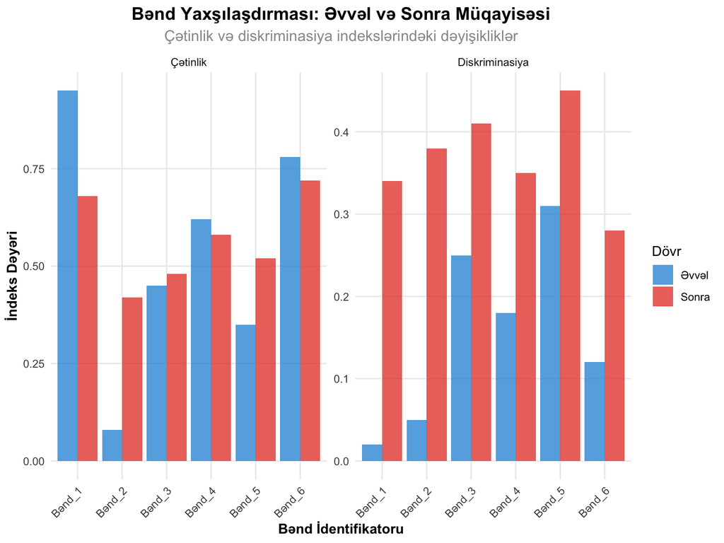

```r
# Yaxşılaşdırmanın vizuallaşdırılması
improvement_long <- data.frame(
  Bənd_ID = rep(before_after_comparison$Bənd_ID, 4),
  Metrik = rep(c("p_Əvvəl", "p_Sonra", "D_Əvvəl", "D_Sonra"), each = 6),
  Dəyər = c(before_after_comparison$Əvvəl_p, before_after_comparison$Sonra_p,
            before_after_comparison$Əvvəl_D, before_after_comparison$Sonra_D),
  Dövr = rep(c("Əvvəl", "Sonra", "Əvvəl", "Sonra"), each = 6),
  Tip = rep(c("Çətinlik", "Çətinlik", "Diskriminasiya", "Diskriminasiya"), each = 6)
)

ggplot(improvement_long, aes(x = Bənd_ID, y = Dəyər, fill = Dövr)) +
  geom_col(position = "dodge", alpha = 0.8) +
  facet_wrap(~Tip, scales = "free_y") +
  scale_fill_manual(values = colors_basic[1:2]) +
  labs(title = "Bənd Yaxşılaşdırması: Əvvəl və Sonra Müqayisəsi",
       subtitle = "Çətinlik və diskriminasiya indekslərindəki dəyişikliklər",
       x = "Bənd İdentifikatoru", y = "İndeks Dəyəri", fill = "Dövr") +
  theme_clean() +
  theme(axis.text.x = element_text(angle = 45, hjust = 1))
```

# 6 R-da Hərtərəfli Çətinlik Analizi

## 6.1 Avtomatik Analiz Funksiyaları

```r
# Hərtərəfli çətinlik analizi funksiyası
comprehensive_difficulty_analysis <- function(data, group_var = NULL) {

  # Əsas çətinlik statistikları
  n_items <- ncol(data)
  n_students <- nrow(data)

  results <- list()

  # 1. Əsas çətinlik indeksləri
  difficulty_indices <- apply(data, 2, function(x) {
    p <- mean(x, na.rm = TRUE)
    se <- sqrt(p * (1 - p) / length(x))
    ci_lower <- p - 1.96 * se
    ci_upper <- p + 1.96 * se

    return(c(p = p, se = se, ci_lower = ci_lower, ci_upper = ci_upper))
  })

  results$difficulty_stats <- t(difficulty_indices)

  # 2. Çətinlik kateqoriyaları
  p_values <- results$difficulty_stats[, "p"]
  categories <- cut(p_values,
                   breaks = c(0, 0.10, 0.29, 0.69, 0.89, 1.0),
                   labels = c("Çox Çətin", "Çətin", "Orta", "Asan", "Çox Asan"),
                   include.lowest = TRUE)

  results$categories <- table(categories)

  # 3. Diskriminasiya analizi
  total_scores <- rowSums(data, na.rm = TRUE)
  n_extreme <- round(0.27 * n_students)

  high_indices <- order(total_scores, decreasing = TRUE)[1:n_extreme]
  low_indices <- order(total_scores, decreasing = FALSE)[1:n_extreme]

  discrimination <- apply(data, 2, function(x) {
    high_p <- mean(x[high_indices], na.rm = TRUE)
    low_p <- mean(x[low_indices], na.rm = TRUE)
    return(high_p - low_p)
  })

  results$discrimination <- discrimination

  # 4. Bənd-ümumi korrelyasiya
  item_total_cor <- apply(data, 2, function(x) {
    total_minus_item <- rowSums(data, na.rm = TRUE) - x
    cor(x, total_minus_item, use = "complete.obs")
  })

  results$item_total_correlation <- item_total_cor

  return(results)
}

# Nümunə məlumatlar üçün analiz
detailed_analysis <- comprehensive_difficulty_analysis(test_data)

# Nəticələrin formatlanması
detailed_results <- data.frame(
  Bənd = paste0("Bənd_", 1:n_items),
  Çətinlik_p = round(detailed_analysis$difficulty_stats[, "p"], 3),
  Standart_Xəta = round(detailed_analysis$difficulty_stats[, "se"], 3),
  Diskriminasiya_D = round(detailed_analysis$discrimination, 3),
  Bənd_Ümumi_r = round(detailed_analysis$item_total_correlation, 3),
  Keyfiyyət_Qiyməti = ifelse(detailed_analysis$discrimination >= 0.30 &
                             detailed_analysis$item_total_correlation >= 0.30, "Əla",
                      ifelse(detailed_analysis$discrimination >= 0.20 &
                             detailed_analysis$item_total_correlation >= 0.20, "Yaxşı", "Zəif"))
)

kable(detailed_results, caption = "Hərtərəfli Bənd Çətinlik və Keyfiyyət Analizi")
```

Hərtərəfli Bənd Çətinlik və Keyfiyyət Analizi

|  | Bənd | Çətinlik_p | Standart_Xəta | Diskriminasiya_D | Bənd_Ümumi_r | Keyfiyyət_Qiyməti |
| --- | --- | --- | --- | --- | --- | --- |
| Bənd_1 | Bənd_1 | 0.93 | 0.026 | 0.148 | 0.071 | Zəif |
| Bənd_2 | Bənd_2 | 0.81 | 0.039 | 0.259 | -0.060 | Zəif |
| Bənd_3 | Bənd_3 | 0.71 | 0.045 | 0.444 | -0.005 | Zəif |
| Bənd_4 | Bənd_4 | 0.61 | 0.049 | 0.481 | -0.071 | Zəif |
| Bənd_5 | Bənd_5 | 0.46 | 0.050 | 0.556 | 0.134 | Zəif |
| Bənd_6 | Bənd_6 | 0.39 | 0.049 | 0.444 | 0.048 | Zəif |
| Bənd_7 | Bənd_7 | 0.35 | 0.048 | 0.259 | -0.037 | Zəif |
| Bənd_8 | Bənd_8 | 0.21 | 0.041 | 0.185 | 0.014 | Zəif |
| Bənd_9 | Bənd_9 | 0.12 | 0.032 | 0.148 | -0.045 | Zəif |
| Bənd_10 | Bənd_10 | 0.11 | 0.031 | 0.222 | 0.164 | Zəif |

```r
# Çətinlik kateqoriyalarının paylanması
category_dist <- data.frame(
  Kateqoriya = names(detailed_analysis$categories),
  Sayı = as.numeric(detailed_analysis$categories),
  Faiz = round(as.numeric(detailed_analysis$categories) / sum(detailed_analysis$categories) * 100, 1)
)

kable(category_dist, caption = "Bəndlərin Çətinlik Kateqoriyalarına Görə Paylanması")
```

Bəndlərin Çətinlik Kateqoriyalarına Görə Paylanması

| Kateqoriya | Sayı | Faiz |
| --- | --- | --- |
| Çox Çətin | 0 | 0 |
| Çətin | 3 | 30 |
| Orta | 4 | 40 |
| Asan | 2 | 20 |
| Çox Asan | 1 | 10 |

## 6.2 Qrafik Analizlər

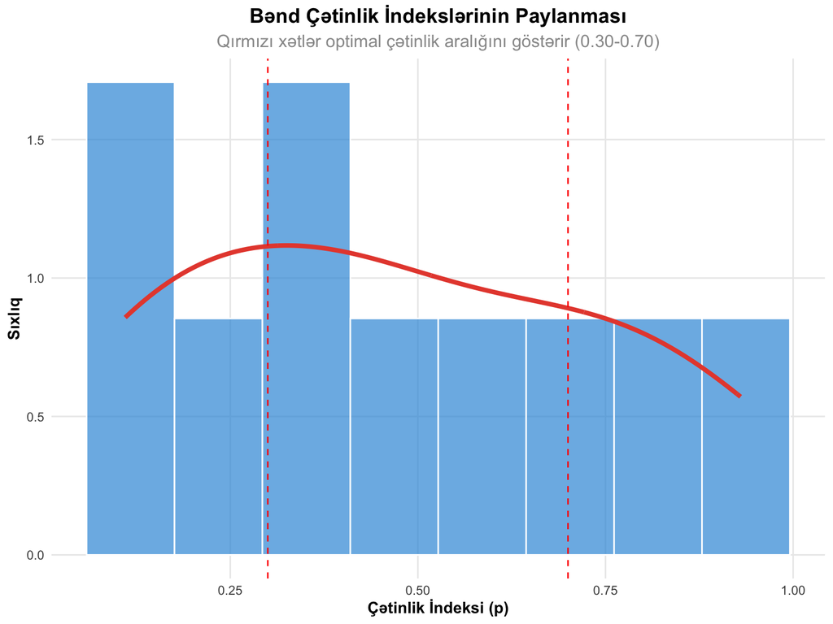

```r
# 1. Çətinlik indekslərinin histogramı
ggplot(detailed_results, aes(x = Çətinlik_p)) +
  geom_histogram(aes(y = after_stat(density)), bins = 8, fill = colors_basic[1],
                 alpha = 0.7, color = "white") +
  geom_density(color = colors_basic[2], size = 1.5) +
  geom_vline(xintercept = c(0.3, 0.7), linetype = "dashed", color = "red") +
  labs(title = "Bənd Çətinlik İndekslərinin Paylanması",
       subtitle = "Qırmızı xətlər optimal çətinlik aralığını göstərir (0.30-0.70)",
       x = "Çətinlik İndeksi (p)", y = "Sıxlıq") +
  theme_clean()
```

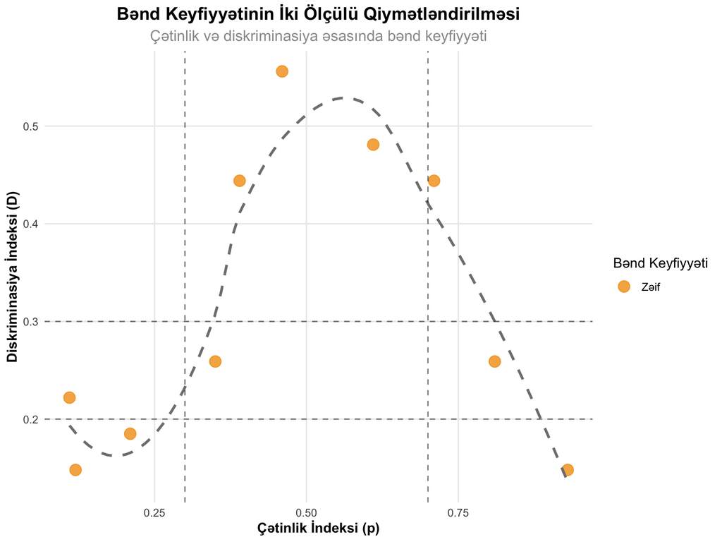

```r
# 2. Çətinlik vs Diskriminasiya scatter plot
ggplot(detailed_results, aes(x = Çətinlik_p, y = Diskriminasiya_D, color = Keyfiyyət_Qiyməti)) +
  geom_point(size = 4, alpha = 0.8) +
  geom_smooth(method = "loess", se = FALSE, color = "gray50", linetype = "dashed") +
  geom_hline(yintercept = c(0.20, 0.30), linetype = "dashed", alpha = 0.5) +
  geom_vline(xintercept = c(0.30, 0.70), linetype = "dashed", alpha = 0.5) +
  scale_color_manual(values = c("Əla" = colors_basic[1], "Yaxşı" = colors_basic[2],
                                "Zəif" = colors_basic[3])) +
  labs(title = "Bənd Keyfiyyətinin İki Ölçülü Qiymətləndirilməsi",
       subtitle = "Çətinlik və diskriminasiya əsasında bənd keyfiyyəti",
       x = "Çətinlik İndeksi (p)", y = "Diskriminasiya İndeksi (D)",
       color = "Bənd Keyfiyyəti") +
  theme_clean()
```

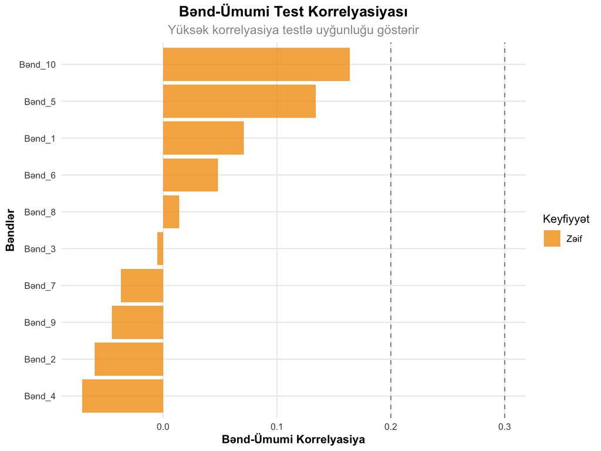

```r
# 3. Bənd-ümumi korrelyasiya analizi
ggplot(detailed_results, aes(x = reorder(Bənd, Bənd_Ümumi_r), y = Bənd_Ümumi_r,
                             fill = Keyfiyyət_Qiyməti)) +
  geom_col(alpha = 0.8) +
  geom_hline(yintercept = c(0.20, 0.30), linetype = "dashed", alpha = 0.5) +
  coord_flip() +
  scale_fill_manual(values = c("Əla" = colors_basic[1], "Yaxşı" = colors_basic[2],
                               "Zəif" = colors_basic[3])) +
  labs(title = "Bənd-Ümumi Test Korrelyasiyası",
       subtitle = "Yüksək korrelyasiya testlə uyğunluğu göstərir",
       x = "Bəndlər", y = "Bənd-Ümumi Korrelyasiya", fill = "Keyfiyyət") +
  theme_clean()
```

# 7 Test Səviyyəsində Çətinlik Analizi

## 7.1 Testin Ümumi Çətinlik Profili

```r
# Test səviyyəsində ümumi statistikalar
test_statistics <- data.frame(
  Statistika = c("Orta Çətinlik", "Çətinlik Standart Sapması", "Çətinlik Aralığı",
                 "Optimal Aralıqda Bənd Sayı", "Yüksək Diskriminasiyalı Bənd Sayı",
                 "Ümumi Test Etibarlılığı"),
  Dəyər = c(
    round(mean(detailed_results$Çətinlik_p), 3),
    round(sd(detailed_results$Çətinlik_p), 3),
    paste(round(min(detailed_results$Çətinlik_p), 3), "-",
          round(max(detailed_results$Çətinlik_p), 3)),
    sum(detailed_results$Çətinlik_p >= 0.30 & detailed_results$Çətinlik_p <= 0.70),
    sum(detailed_results$Diskriminasiya_D >= 0.30),
    round(psych::alpha(test_data)$total$raw_alpha, 3)
  )
)
```

```
## Some items ( Bənd_3 Bənd_4 Bənd_6 ) were negatively correlated with the first principal component and
## probably should be reversed.
## To do this, run the function again with the 'check.keys=TRUE' option
```

```r
kable(test_statistics, caption = "Testin Ümumi Çətinlik və Keyfiyyət Profili")
```

Testin Ümumi Çətinlik və Keyfiyyət Profili

| Statistika | Dəyər |
| --- | --- |
| Orta Çətinlik | 0.47 |
| Çətinlik Standart Sapması | 0.288 |
| Çətinlik Aralığı | 0.11 - 0.93 |
| Optimal Aralıqda Bənd Sayı | 4 |
| Yüksək Diskriminasiyalı Bənd Sayı | 4 |
| Ümumi Test Etibarlılığı | 0.051 |

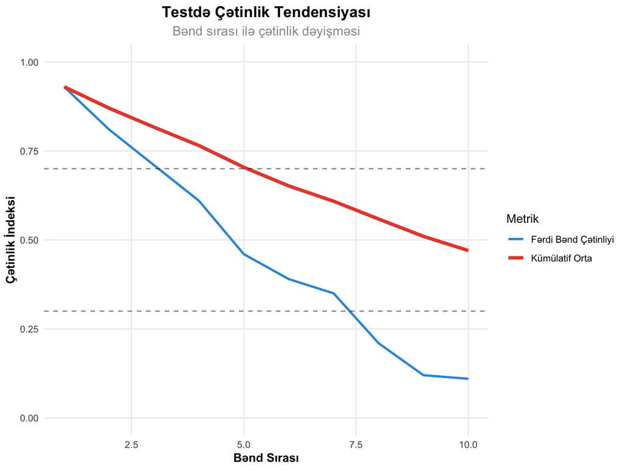

```r
# Çətinlik indekslərinin test boyunca dəyişməsi
item_order_analysis <- data.frame(
  Bənd_Sırası = 1:n_items,
  Çətinlik_p = detailed_results$Çətinlik_p,
  Diskriminasiya_D = detailed_results$Diskriminasiya_D,
  Kümülatif_Orta_Çətinlik = cumsum(detailed_results$Çətinlik_p) / (1:n_items)
)

# Test boyunca çətinlik tendensiyası
ggplot(item_order_analysis, aes(x = Bənd_Sırası)) +
  geom_line(aes(y = Çətinlik_p, color = "Fərdi Bənd Çətinliyi"), size = 1) +
  geom_line(aes(y = Kümülatif_Orta_Çətinlik, color = "Kümülatif Orta"), size = 1.5) +
  geom_hline(yintercept = c(0.30, 0.70), linetype = "dashed", alpha = 0.5) +
  scale_color_manual(values = c("Fərdi Bənd Çətinliyi" = colors_basic[1],
                                "Kümülatif Orta" = colors_basic[2])) +
  labs(title = "Testdə Çətinlik Tendensiyası",
       subtitle = "Bənd sırası ilə çətinlik dəyişməsi",
       x = "Bənd Sırası", y = "Çətinlik İndeksi", color = "Metrik") +
  theme_clean() +
  ylim(0, 1)
```

## 7.2 Çətinlik Profilinin Optimallaşdırılması

```r
# Testin optimallaşdırılması üçün tövsiyələr
optimization_analysis <- detailed_results %>%
  mutate(
    Tövsiyə = case_when(
      Çətinlik_p > 0.90 ~ "Çətinləşdir (p > 0.90)",
      Çətinlik_p < 0.10 ~ "Asanlaşdır (p < 0.10)",
      Diskriminasiya_D < 0.20 ~ "Diskriminasiyanı artır (D < 0.20)",
      Bənd_Ümumi_r < 0.20 ~ "Bəndi yenidən yaz (r < 0.20)",
      TRUE ~ "Saxla (yaxşı keyfiyyət)"
    ),
    Prioritet = case_when(
      Çətinlik_p > 0.90 | Çətinlik_p < 0.10 ~ "Yüksək",
      Diskriminasiya_D < 0.20 | Bənd_Ümumi_r < 0.20 ~ "Orta",
      TRUE ~ "Aşağı"
    )
  )

# Tövsiyələrin xülasəsi
recommendation_summary <- optimization_analysis %>%
  count(Tövsiyə, Prioritet) %>%
  arrange(Prioritet, desc(n))

kable(recommendation_summary, caption = "Test Optimallaşdırması üçün Tövsiyələr")
```

Test Optimallaşdırması üçün Tövsiyələr

| Tövsiyə | Prioritet | n |
| --- | --- | --- |
| Bəndi yenidən yaz (r < 0.20) | Orta | 7 |
| Diskriminasiyanı artır (D < 0.20) | Orta | 2 |
| Çətinləşdir (p > 0.90) | Yüksək | 1 |

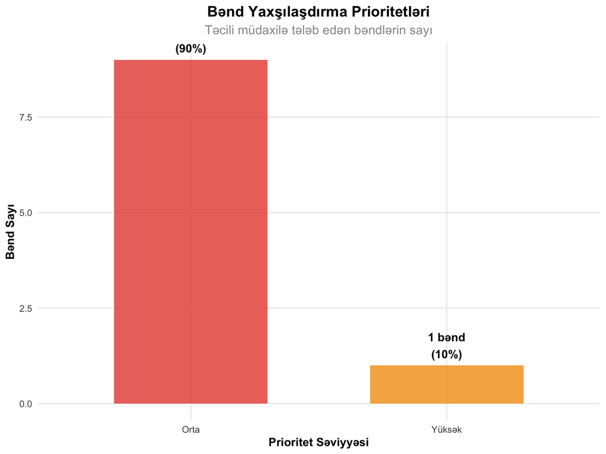

```r
# Prioritet əsasında bəndlərin təsnifatı
priority_breakdown <- optimization_analysis %>%
  count(Prioritet) %>%
  mutate(Faiz = round(n/sum(n)*100, 1))

ggplot(priority_breakdown, aes(x = Prioritet, y = n, fill = Prioritet)) +
  geom_col(alpha = 0.8, width = 0.6) +
  geom_text(aes(label = paste0(n, " bənd\n(", Faiz, "%)")),
            vjust = -0.3, fontface = "bold") +
  scale_fill_manual(values = c("Yüksək" = colors_basic[3],
                               "Orta" = colors_basic[2],
                               "Aşağı" = colors_basic[1])) +
  labs(title = "Bənd Yaxşılaşdırma Prioritetləri",
       subtitle = "Təcili müdaxilə tələb edən bəndlərin sayı",
       x = "Prioritet Səviyyəsi", y = "Bənd Sayı", fill = "Prioritet") +
  theme_clean() +
  theme(legend.position = "none")
```

# 8 Çətinlik Analizində Xüsusi Hallar

## 8.1 Qrup Fərqliliklərinin Analizi

```r
# Müxtəlif qruplar üçün çətinlik analizi (simulyasiya)
set.seed(789)

# Qrup dəyişənlərinin yaradılması (məsələn, cins)
gender <- sample(c("Kişi", "Qadın"), n_students, replace = TRUE)
academic_level <- sample(c("Aşağı", "Orta", "Yüksək"), n_students, replace = TRUE)

# Qruplara görə çətinlik fərqliliklərinin analizi
group_analysis <- data.frame()

for(i in 1:n_items) {
  item_data <- data.frame(
    Score = test_data[, i],
    Gender = gender,
    Academic_Level = academic_level
  )

  # Cinsə görə fərq
  gender_diff <- item_data %>%
    group_by(Gender) %>%
    summarise(p = mean(Score), .groups = 'drop') %>%
    summarise(diff = abs(diff(p))) %>%
    pull(diff)

  # Akademik səviyyəyə görə fərq
  academic_analysis <- item_data %>%
    group_by(Academic_Level) %>%
    summarise(p = mean(Score), .groups = 'drop')

  academic_range <- max(academic_analysis$p) - min(academic_analysis$p)

  temp_result <- data.frame(
    Bənd = paste0("Bənd_", i),
    Cins_Fərqi = round(gender_diff, 3),
    Akademik_Aralıq = round(academic_range, 3),
    Potensial_Bias = ifelse(gender_diff > 0.10 | academic_range > 0.30, "Bəli", "Xeyr")
  )

  group_analysis <- rbind(group_analysis, temp_result)
}

kable(group_analysis, caption = "Qrup Fərqliliklərinin Çətinlik Analizində Nəzərdən Keçirilməsi")
```

Qrup Fərqliliklərinin Çətinlik Analizində Nəzərdən Keçirilməsi

| Bənd | Cins_Fərqi | Akademik_Aralıq | Potensial_Bias |
| --- | --- | --- | --- |
| Bənd_1 | 0.050 | 0.077 | Xeyr |
| Bənd_2 | 0.058 | 0.057 | Xeyr |
| Bənd_3 | 0.192 | 0.101 | Bəli |
| Bənd_4 | 0.267 | 0.116 | Bəli |
| Bənd_5 | 0.025 | 0.144 | Xeyr |
| Bənd_6 | 0.025 | 0.192 | Xeyr |
| Bənd_7 | 0.042 | 0.147 | Xeyr |
| Bənd_8 | 0.017 | 0.248 | Xeyr |
| Bənd_9 | 0.033 | 0.125 | Xeyr |
| Bənd_10 | 0.058 | 0.123 | Xeyr |

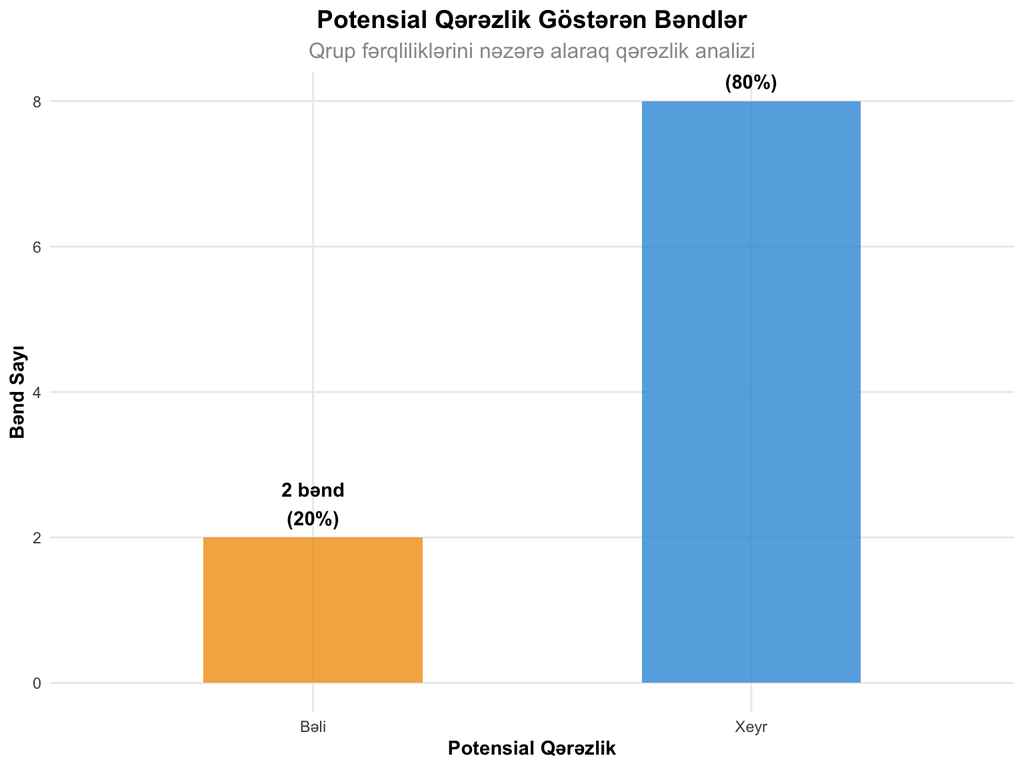

```r
# Bias potensialı olan bəndlərin vizuallaşdırılması
bias_summary <- group_analysis %>%
  count(Potensial_Bias) %>%
  mutate(Faiz = round(n/sum(n)*100, 1))

ggplot(bias_summary, aes(x = Potensial_Bias, y = n, fill = Potensial_Bias)) +
  geom_col(alpha = 0.8, width = 0.5) +
  geom_text(aes(label = paste0(n, " bənd\n(", Faiz, "%)")),
            vjust = -0.3, fontface = "bold") +
  scale_fill_manual(values = c("Bəli" = colors_basic[3], "Xeyr" = colors_basic[1])) +
  labs(title = "Potensial Qərəzlik Göstərən Bəndlər",
       subtitle = "Qrup fərqliliklərini nəzərə alaraq qərəzlik analizi",
       x = "Potensial Qərəzlik", y = "Bənd Sayı", fill = "Qərəzlik") +
  theme_clean() +
  theme(legend.position = "none")
```

## 8.2 Çətinlik Dəyişkənliyinin Temporal Analizi

```r
# Müxtəlif tətbiq vaxtlarında çətinlik dəyişkənliyi simulyasiyası
time_periods <- c("Səhər", "Günorta", "Axşam")
temporal_difficulty <- data.frame()

for(period in time_periods) {
  # Hər vaxt üçün fərqli çətinlik səviyyələri
  time_effect <- switch(period,
                       "Səhər" = 0.05,      # Səhər daha asan
                       "Günorta" = 0.00,    # Bazis
                       "Axşam" = -0.03)     # Axşam bir az çətin

  period_difficulties <- pmax(0.05, pmin(0.95,
                              observed_difficulties + rnorm(n_items, time_effect, 0.02)))

  temp_data <- data.frame(
    Bənd = paste0("Bənd_", 1:n_items),
    Vaxt_Dövri = period,
    Çətinlik_p = round(period_difficulties, 3)
  )

  temporal_difficulty <- rbind(temporal_difficulty, temp_data)
}

# Temporal dəyişkənliyin analizi
temporal_summary <- temporal_difficulty %>%
  group_by(Vaxt_Dövri) %>%
  summarise(
    Orta_Çətinlik = round(mean(Çətinlik_p), 3),
    SD_Çətinlik = round(sd(Çətinlik_p), 3),
    Min_Çətinlik = round(min(Çətinlik_p), 3),
    Max_Çətinlik = round(max(Çətinlik_p), 3),
    .groups = 'drop'
  )

kable(temporal_summary, caption = "Tətbiq Vaxtına Görə Çətinlik Dəyişkənliyi")
```

Tətbiq Vaxtına Görə Çətinlik Dəyişkənliyi

| Vaxt_Dövri | Orta_Çətinlik | SD_Çətinlik | Min_Çətinlik | Max_Çətinlik |
| --- | --- | --- | --- | --- |
| Axşam | 0.447 | 0.278 | 0.089 | 0.867 |
| Günorta | 0.474 | 0.298 | 0.080 | 0.935 |
| Səhər | 0.523 | 0.277 | 0.166 | 0.950 |

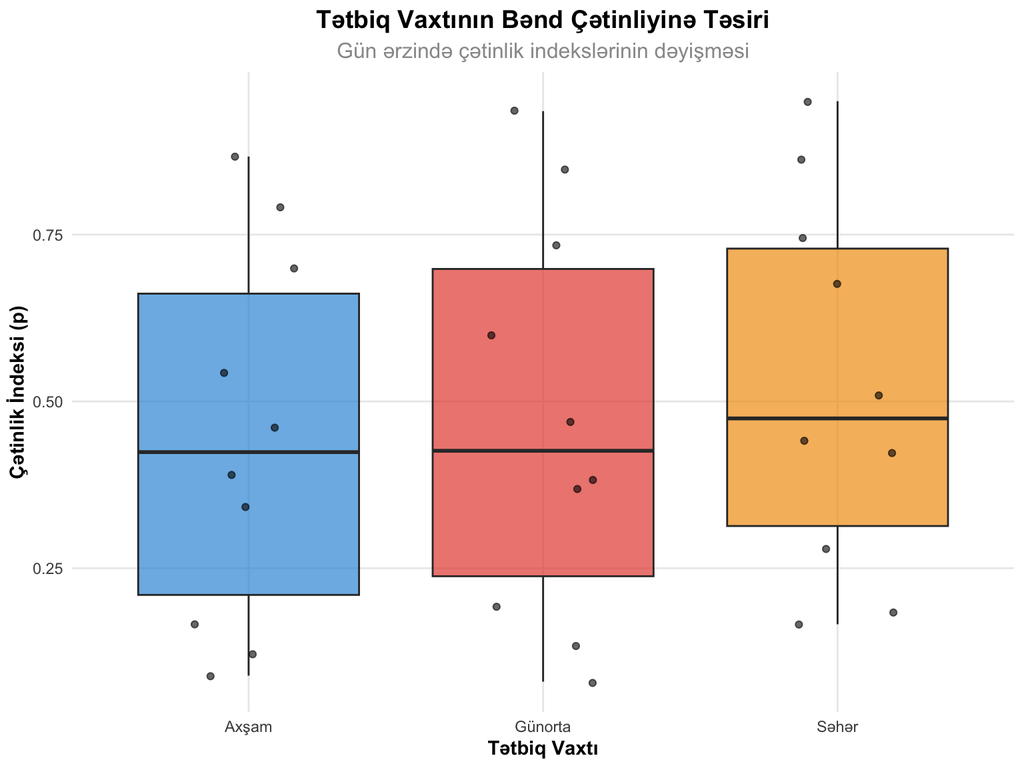

```r
# Temporal dəyişkənliyin vizuallaşdırılması
ggplot(temporal_difficulty, aes(x = Vaxt_Dövri, y = Çətinlik_p, fill = Vaxt_Dövri)) +
  geom_boxplot(alpha = 0.7) +
  geom_point(position = position_jitter(width = 0.2), alpha = 0.6) +
  scale_fill_manual(values = colors_basic[1:3]) +
  labs(title = "Tətbiq Vaxtının Bənd Çətinliyinə Təsiri",
       subtitle = "Gün ərzində çətinlik indekslərinin dəyişməsi",
       x = "Tətbiq Vaxtı", y = "Çətinlik İndeksi (p)", fill = "Vaxt Dövri") +
  theme_clean() +
  theme(legend.position = "none")
```

# 9 Dərsin Xülasəsi

## 9.1 Əsas Nəticələr

**Çətinlik İndeksinin Mahiyyəti:** - ✓ **p = (# doğru cavab)/(# total)** - bənd çətinliyinin ölçülməsi - ✓ **0 ≤ p ≤ 1** - yüksək p = asan, aşağı p = çətin - ✓ **Optimal aralıq** - p = 0.30-0.70 maksimum diskriminasiya üçün

**Çətinlik və Diskriminasiya Əlaqəsi:** - ✓ **p = 0.50** - maksimum diskriminasiya potensialı - ✓ **Hərtərəfli analiz** - çətinlik + diskriminasiya + etibarlılıq - ✓ **Test məqsədi** - çətinlik səviyyəsini təyin edir

**Praktik Tətbiqlər:** - ✓ R-da avtomatik çətinlik analizi - ✓ Bənd keyfiyyətinin qiymətləndirilməsi  
- ✓ Test optimallaşdırma strategiyaları

# 10 Ev Tapşırığı

## 10.1 Tapşırıq 1: Nəzəri Hissə (25 xal)

1. **Çətinlik indeksinin konseptual anlamı** nədir? Niyə p = 0.50 optimal diskriminasiya təmin edir? (200 söz)
2. **Müxtəlif test növləri** üçün optimal çətinlik səviyyələri fərqlənir. Qəbul imtahanları və dərsdaxili qiymətləndirmə arasındakı fərqi izah edin. (250 söz)
3. **Tavanefekti və döşəməefekti** problemi nədir? Bu problemlər diskriminasiyanı necə təsir edir? (200 söz)

## 10.2 Tapşırıq 2: R Analiz Məşqi (50 xal)

```r
# Çətinlik analizi tapşırığı
set.seed(sizin_tələbə_nömrəniz)

# Verilmiş test məlumatları (15 bənd, 80 tələbə)
n_students <- 80
n_items <- 15

# Məlumatları yaradın (çətinlik səviyyələri 0.1-dən 0.9-a qədər)
true_difficulties <- seq(0.1, 0.9, length.out = n_items)

test_responses <- matrix(NA, nrow = n_students, ncol = n_items)
for(i in 1:n_items) {
  test_responses[, i] <- rbinom(n_students, 1, true_difficulties[i])
}

# TAPŞİRIQLAR:
# 1. Hər bənd üçün çətinlik indeksini hesablayın
# 2. Çətinlik kateqoriyalarına təsnif edin (çox asan, asan, orta, çətin, çox çətin)
# 3. Üst %27 və alt %27 qrupları ilə diskriminasiya indeksini hesablayın
# 4. Bənd-ümumi test korrelyasiyasını hesablayın
# 5. Hər bənd üçün keyfiyyət qiyməti verin (əla/yaxşı/zəif)

# CAVABLARINIZI BU FORMATDA VERİN:
analysis_results <- data.frame(
  Bənd = paste0("Bənd_", 1:n_items),
  Çətinlik_p = , # Doldurun
  Kateqoriya = , # Doldurun
  Diskriminasiya_D = , # Doldurun
  Bənd_Ümumi_r = , # Doldurun
  Keyfiyyət = # Doldurun
)

# ƏLAVƏ HESABLAMALAR:
print("Ümumi test statistikaları:")
print(paste("Orta çətinlik:", ))
print(paste("Optimal aralıqda bənd sayı:", ))
print(paste("Yüksək keyfiyyətli bənd sayı:", ))

# BONUS: Çətinlik optimallaşdırma tövsiyələri hazırlayın
```

## 10.3 Tapşırıq 3: Bənd Yaxşılaşdırma Planı (25 xal)

Aşağıdakı problemli bəndlər üçün yaxşılaşdırma planı hazırlayın:

**Bənd A:** p = 0.95, D = 0.08 (çox asan, zəif diskriminasiya)  
**Bənd B:** p = 0.12, D = 0.05 (çox çətin, zəif diskriminasiya)  
**Bənd C:** p = 0.55, D = 0.15 (optimal çətinlik, zəif diskriminasiya)

Hər bənd üçün: - Problem təhlili (100 söz) - Konkret yaxşılaşdırma təklifləri (150 söz)  
- Gözlənilən nəticələr (50 söz)

# 11 Növbəti Dərslərə Hazırlıq

## 11.1 Dərs 12: “Bənd Diskriminasiya İndeksi”

Növbəti dərsdə öyrənəcəklər:

- ✓ Diskriminasiya indeksinin hesablanması (D = p_yüksək - p_aşağı)
- ✓ Üst və alt qrupların təyini (%27 metodu)
- ✓ Diskriminasiya və etibarlılıq əlaqəsi
- ✓ Neqativ diskriminasiyalı bəndlərin problemi

## 11.2 Dərs 13: “Bənd-Ümumi Test Korrelyasiyası”

Sonrakı mövzular:

- ✓ Point-biserial korrelyasiya
- ✓ Bənd seçimi meyarları
- ✓ Corrected item-total correlation
- ✓ Alpha-if-item-deleted analizi

# 12 Əlavə Tədqiqat Materialları

## 12.1 Əsas Ədəbiyyat

**Məcburi oxu:** - Allen, M.J., & Yen, W.M. (2002). *Introduction to Measurement Theory*. Fəsil 5: “Item Analysis” - Crocker, L., & Algina, J. (2008). Fəsil 8: “Item Analysis in the Classical Framework”

**Tövsiyə olunan:** - Ebel, R.L., & Frisbie, D.A. (1991). *Essentials of Educational Measurement*. Fəsil 11 - Nitko, A.J., & Brookhart, S.M. (2011). *Educational Assessment of Students*. Fəsil 13